```python
import numpy as np
import matplotlib
import matplotlib.pyplot as plt
import scipy
from scipy import stats
from scipy import optimize
import h5py
import pandas as pd
```

# Lab 4

## Problem 1

### (1)

```python
hf = h5py.File("gammaray_lab4.h5", 'r')
data = np.array(hf.get('data'))
t = data[0]
phase = data[1]
long = data[2]
counts = data[3]
hf.close()
```

Looking at the histograms below, there is no obvious sign of signal contamination (anomolous outliers, long tail, etc), so extracting our background shouldn't require any signal exclusion. However, we do note that the distribution differs noticeably from the expected Poisson shape. We will give an explanation for this in a moment.

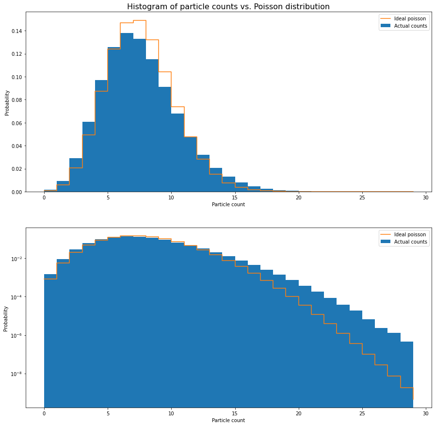

```python
x = np.arange(0,30)
mean = counts.mean()

fig, axs = plt.subplots(2,1, figsize=(15,15))

axs[1].set_yscale('log')
for ax in axs:
    ax.hist(counts, x, density=True, label="Actual counts")
    ax.step(x, stats.poisson(mu=mean).pmf(x), where='post', label="Ideal poisson")
    ax.set_xlabel("Particle count")
    ax.set_ylabel("Probability")
    ax.legend()

axs[0].set_title("Histogram of particle counts vs. Poisson distribution", fontsize=16);
```

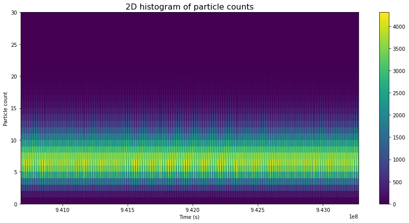

```python
fig, ax = plt.subplots(1,1, figsize=(15,7))

_, _, _, img = ax.hist2d(t, counts, [1000,30], [[t[0], t[-1]],[0,30]])

ax.set_xlabel("Time (s)")
ax.set_ylabel("Particle count")
ax.set_title("2D histogram of particle counts", fontsize=16)

fig.colorbar(img);
```

Above we have plotted a 2D histogram showing how the distribution of particle counts changes over time. The granularity is too low to make anything out in detail, but some kind of time-dependence is apparent, with evidence of periodicity. This gives a potential explanation for the unexpected shape of the distribution from before: if the background is Poisson at any given time but with a time-dependent mean, then the aggregate time-averaged distribution will *not* be Poisson. Assuming that this is what's happening, all we need to do to model the background is characterize how the mean varies with time. This is done in the next section.

For completeness, we also plot below the solar phase and earth longitude of the satellite over an arbitrary 10,000 second window, and find as expected that both vary linearly, completing approximately two full 360 degree rotations in the selected window.

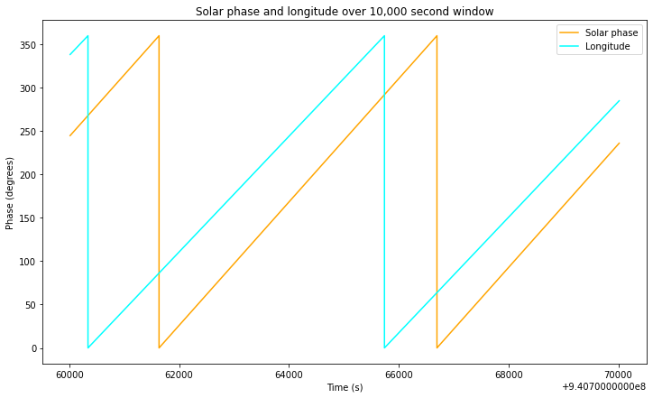

```python
start = int(8e5)
end = int(9e5)

fig, ax = plt.subplots(1,1, figsize=(12,7))

ax.plot(t[start:end], phase[start:end], label="Solar phase", color='orange')
ax.plot(t[start:end], long[start:end], label="Longitude", color='cyan')
ax.set_xlabel("Time (s)")
ax.set_ylabel("Phase (degrees)")
ax.set_title("Solar phase and longitude over 10,000 second window")

ax.legend();
```

### (2)

It's clear from the 2D histogram above that whatever time-dependence exists is happening over a relatively short period (compared to the whole observing time) so to get a clearer picture we need to look at a smaller time window. Below is a 2D histogram zoomed in to a 30,000 second window, with the solar phase and longitude overlaid to look for correlations.

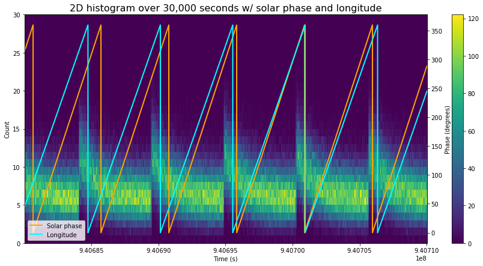

```python
start = int(0e5)
end = int(3e5)

fig, ax0 = plt.subplots(1,1, figsize=(15,7))
_, _, _, img = ax0.hist2d(t[start:end], counts[start:end], [500,30], [[t[start], t[end]],[0,30]])

ax0.set_xlabel("Time (s)")
ax0.set_ylabel("Count")
ax0.set_title("2D histogram over 30,000 seconds w/ solar phase and longitude", fontsize=16)

ax1 = ax0.twinx()
ax1.plot(t[start:end], phase[start:end], label="Solar phase", color='orange', linewidth=2)
ax1.plot(t[start:end], long[start:end], label="Longitude", color='cyan', linewidth=2)

ax1.set_ylabel("Phase (degrees)")

ax1.legend()
fig.colorbar(img, ax=ax0);
```

We see that the variation in background appears to be synchronized with the longitude of the satellite. In particular, the rate of events suddenly increases each time the longitude passes about 315 degrees, then gradually decreases over the next 90 minutes before repeating. We would thus like to examine the rate of events versus the longitude, but the fact that the abrupt changes in event rate do not align with the 360 degree/0 degree crossover in the longitude makes this inconvenient. As a remedy, we introduce a "longitude parameter" $\rho$ which is related to the longitude $l$, expressed as before in degrees, by

$$\rho = \frac{(l + 45) \% 360}{360}$$

We have chosen this formula so that $\rho$ varies from 0, when the event rate is highest, to 1, when the event rate is lowest. We can now create a new 2D histogram of particle counts vs $\rho$ with overlaid mean.

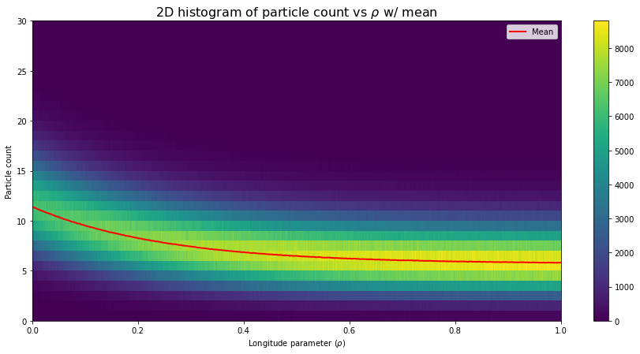

```python
rho = ((long + 45) % 360) / 360

fig, ax = plt.subplots(1,1, figsize=(15,7))
h, xedge, yedge, img = ax.hist2d(rho, counts, [500,30], [[0, 1],[0,30]])

# find bin centers from bin edges
x = (xedge[1:] + xedge[:-1]) / 2
y = yedge[:-1]

means = np.sum(np.matmul(h, np.diag(y)), axis=1) / np.sum(h, axis=1)
ax.plot(x, means, color='red', linewidth=2, label="Mean")

ax.set_xlabel(r"Longitude parameter ($\rho$)")
ax.set_ylabel("Particle count")
ax.set_title(r"2D histogram of particle count vs $\rho$ w/ mean", fontsize=16)
ax.legend()

fig.colorbar(img);
```

At a glance, the mean appears approximately exponential in $\rho$, and indeed we find a very good fit with the following parameters:

$$\mu = \exp\left(-\frac{\rho - 0.4354}{0.2503}\right) + 5.698$$

```
x loc: 0.4353505142436041 	 y loc: 5.698326498266152 	 scale: 0.25028063934508826
```

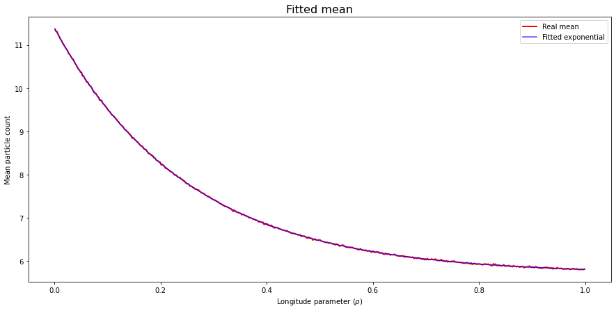

```python
def mean_test(x, xloc, yloc, scale):
    return np.exp(-(x - xloc) / scale) + yloc

[xloc, yloc, scale], _ = optimize.curve_fit(mean_test, x, means)
print(f"x loc: {xloc} \t y loc: {yloc} \t scale: {scale}")
mean_fit = lambda x: mean_test(x, xloc, yloc, scale)

fig, ax = plt.subplots(1,1, figsize=(15,7))
ax.plot(x, means, color='r', linewidth=2, label="Real mean")
ax.plot(x, mean_fit(x), color='b', alpha=0.7, label="Fitted exponential")

ax.set_xlabel(r"Longitude parameter ($\rho$)")
ax.set_ylabel("Mean particle count")
ax.set_title("Fitted mean", fontsize=16)
ax.legend();
```

We thus model the background distribution at any given time as a Poisson distribution with mean $\mu$ as given above. This model is compared to the real distribution for various values of $\rho$ in the graphs below. (To get a large enough sample for these real distributions we take all data points which have a $\rho$ of within 0.01 of the chosen value.) We see that our model fits the real data very well, confirming our earlier hypothesis that the background is locally Poisson.

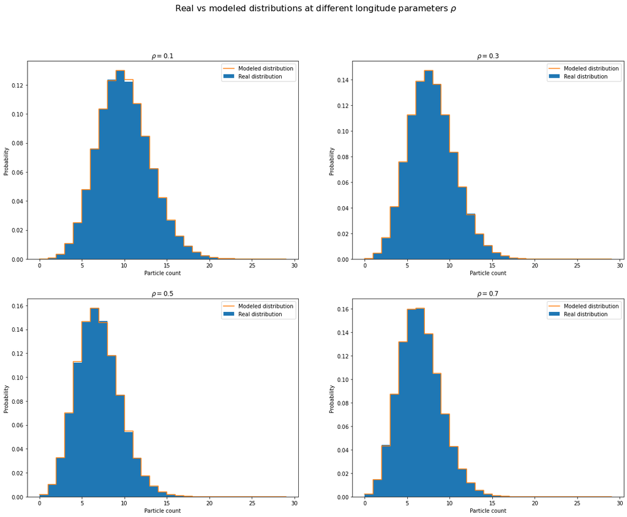

```python
fig, axs = plt.subplots(2,2, figsize=(20,15))

width = 0.01
ps = [0.1, 0.3, 0.5, 0.7]
for p, ax in zip(ps, axs.flatten()):
    filtered = counts[np.abs(p - rho) < width]
    mean = filtered.mean()
    x = np.arange(0,30)
    ax.hist(filtered, x, density=True, label="Real distribution")
    ax.step(x, stats.poisson.pmf(x, mu=mean_fit(p)), where='post', label="Modeled distribution")
    ax.set_xlabel("Particle count")
    ax.set_ylabel("Probability")
    ax.set_title(f"$\\rho = {p}$")
    ax.legend()

fig.suptitle("Real vs modeled distributions at different longitude parameters $\\rho$", fontsize=16);
```

### (4)

We are interested in the probability that the background would produce a particle count as high or higher than a candidate signal. Since the background depends on $\rho$, so too will the 5 sigma threshold. This dependence is graphed below. (To determine whether a 100 ms candidate event is significant, one would look at the longitude of the satellite at the time of the event, calculate $\rho$ from that, then look up the corresponding threshold on the graph below and compare it to the candidate.)

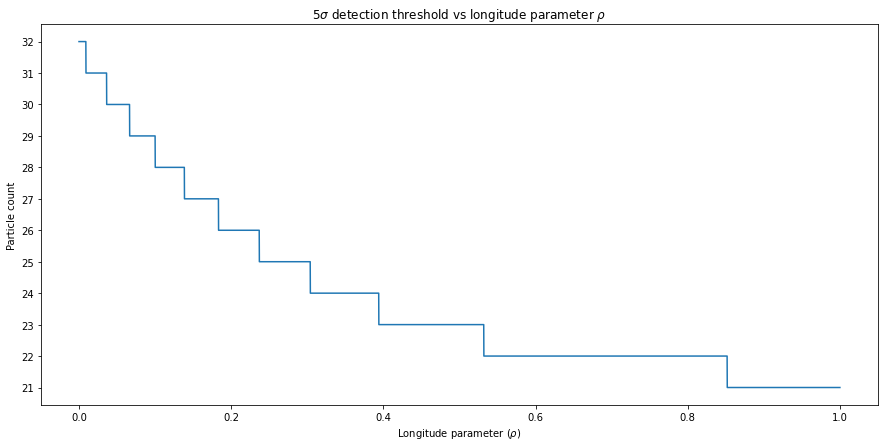

```python
prob = stats.norm.sf(5)
p = np.linspace(0,1,5000)
threshold = stats.poisson.isf(prob, mu=mean_fit(p))

fig, ax = plt.subplots(1,1, figsize=(15,7))
ax.plot(p, threshold)
ax.set_xlabel(r"Longitude parameter ($\rho$)")
ax.set_ylabel("Particle count")
ax.set_yticks(np.arange(21,33))
ax.set_title(r"$5\sigma$ detection threshold vs longitude parameter $\rho$");
```

## Problem 2

### (1)

```python
hf = h5py.File("images.h5", 'r')
images = np.array(hf['imagestack'])
all_pixels = images.flatten()
hf.close()
```

### (2)

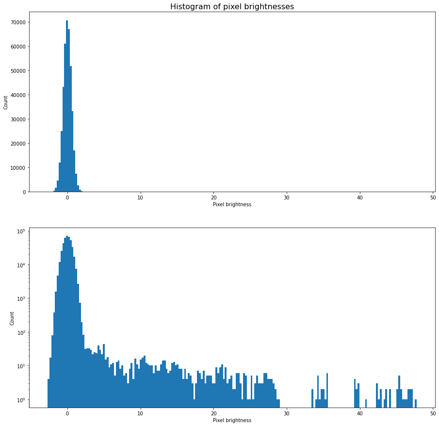

```python
fig, axs = plt.subplots(2,1, figsize=(15,15))
axs[1].set_yscale('log')
for ax in axs:
    ax.hist(all_pixels, 200)
    ax.set_xlabel("Pixel brightness")
    ax.set_ylabel("Count")
axs[0].set_title("Histogram of pixel brightnesses", fontsize=16);
```

In the logarithmic histogram, we can clearly see a normal distribution at low brightness, corresponding to sensor noise, as well as a long tail of bright objects. First, we want to extract the parameters of this gaussian sensor noise. The long tail seems to begin above a brightness of about 2.5, so we will throw away all pixels brighter than this and fit a normal distribution to what remains.

```
Mean: 0.0007128106713321995 	 Stdev: 0.5620767958092459
```

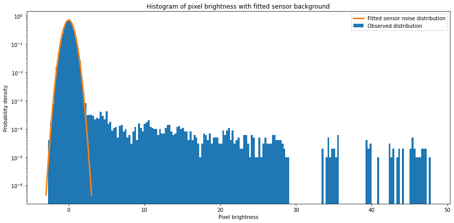

```python
background_pixels = all_pixels[all_pixels < 2.5]
mean = background_pixels.mean()
stdev = background_pixels.std()
print(f"Mean: {mean} \t Stdev: {stdev}")

background = stats.norm(loc=mean, scale=stdev)

fig, ax = plt.subplots(1,1, figsize=(15,7))
ax.set_yscale('log')

ax.hist(all_pixels, 200, density=True, label="Observed distribution")

x = np.linspace(-3, 3, 100)
ax.plot(x, background.pdf(x), linewidth=3, label="Fitted sensor noise distribution")

ax.set_xlabel("Pixel brightness")
ax.set_ylabel("Probability density")
ax.set_title("Histogram of pixel brightness with fitted sensor background")

ax.legend();
```

Repeating this process with all 10 images individually, we get similar parameters as when done collectively, indicating that the sensor noise is consistent across images.

```python
print("Mean \t\t Stdev \n------------------------")
for i in np.arange(0,10):
    pixels = images[:,:,i].flatten()
    background_pixels = pixels[pixels < 2.5]
    mean = background_pixels.mean()
    stdev = background_pixels.std()
    print(f"{mean:.3} \t {stdev:.3}")
```

```
Mean 		 Stdev
------------------------
-0.00241 	 0.563
-0.00204 	 0.562
0.00505 	 0.561
0.000983 	 0.563
0.00192 	 0.563
0.00517 	 0.561
-0.00447 	 0.559
-0.000749 	 0.563
0.000756 	 0.562
0.00293 	 0.562
```

However, we are not interested in bright pixels, we are interested in *changes* in pixel brightness. This means we will have a different background for each pixel depending on its "base" brightness. To determine these backgrounds we make two assumptions. First, we assume that no transient appears in multiple images, so we can get a signal-free background for a pixel simply by throwing away the brightest value that pixel takes out of the ten images. Second, we assume that the width of the signal noise does not depend on pixel brightness, so we only need to individually determine the mean of the background for each pixel, and can use the aggregate standard deviation calculated above (0.56) for all pixels.

```python
candidate_val = np.amax(images, axis=2)
candidate_ind = np.argmax(images, axis=2)
candidate_ind_flat = np.arange(0,400000,10) + candidate_ind.flatten()
background_images = np.delete(images, candidate_ind_flat)
background_images.resize(200,200,9)
means = background_images.mean(axis=2)
```

### (3)

Using the means found above, we can calculate the significance of the brightest value taken by each pixel (i.e. the same candidates we excluded when determining our background).

```python
sigmas = (candidate_val - means) / stdev

multind = pd.MultiIndex.from_product([np.arange(200), np.arange(200)], names=["x","y"])
candidates = pd.DataFrame({
    "Image #": candidate_ind.flatten() + 1,
    "Value": candidate_val.flatten(),
    "Mean": means.flatten(),
    "Significance": sigmas.flatten(),
}, index=multind)

candidates[candidates["Significance"] > 4].sort_values("Significance", ascending=False)
```

| x | y | Image # | Value | Mean | Significance |
| --- | --- | --- | --- | --- | --- |
| 112 | 58 | 2 | 2.777002 | -0.072714 | 5.067363 |
| 109 | 123 | 7 | 2.256868 | -0.540602 | 4.974459 |
| 118 | 174 | 6 | 2.257625 | -0.297364 | 4.543279 |
| 172 | 63 | 2 | 2.214150 | -0.334288 | 4.531631 |
| 161 | 51 | 8 | 2.521123 | 0.016317 | 4.454043 |
| 140 | 33 | 2 | 1.993556 | -0.444855 | 4.335981 |
| 61 | 163 | 10 | 2.185620 | -0.241599 | 4.316079 |
| 196 | 91 | 8 | 2.114585 | -0.286839 | 4.270210 |
| 17 | 120 | 10 | 2.576500 | 0.201674 | 4.222914 |
| 119 | 35 | 6 | 2.267410 | -0.103181 | 4.215383 |
| 158 | 5 | 6 | 2.065161 | -0.301312 | 4.208061 |
| 150 | 36 | 4 | 1.902025 | -0.457832 | 4.196295 |
| 82 | 122 | 1 | 2.002156 | -0.357194 | 4.195394 |
| 170 | 37 | 8 | 2.275051 | -0.070992 | 4.171731 |
| 17 | 52 | 6 | 12.461414 | 10.136523 | 4.134120 |
| 149 | 167 | 8 | 2.146584 | -0.166971 | 4.113962 |
| 111 | 138 | 1 | 2.203130 | -0.087484 | 4.073166 |
| 17 | 23 | 7 | 2.095387 | -0.192170 | 4.067732 |
| 0 | 127 | 9 | 1.939775 | -0.347073 | 4.066470 |
| 16 | 97 | 5 | 1.819544 | -0.462231 | 4.057452 |
| 180 | 50 | 3 | 2.089472 | -0.185687 | 4.045686 |
| 130 | 177 | 2 | 2.127084 | -0.147721 | 4.045057 |
| 20 | 11 | 8 | 1.995368 | -0.271179 | 4.030372 |
| 192 | 192 | 7 | 1.993227 | -0.260961 | 4.008396 |

In fact, we must note that the significances listed above only considers each pixel individually, with no trials factor correction. Given that our search covers 40,000 pixels, the aggregate significance of the event at (112,58) is only 2.4 sigma. (That is, there is a 0.8% chance that sensor noise would produce a fluctuation as large as is seen at (112,58) or larger in at least *one* of the 40,000 pixels in the image.) In light of this, we cannot confidently claim a detection of *any* transient event from these data.

```python
prob = stats.norm.sf(5.067) * 40000
sigma = stats.norm.isf(prob)
print(f"{prob:.4} \t {sigma:.3}")
```

```
0.008083 	 2.41
```

### (4)

As noted above, I am searching for changes in pixel brightness, whereas my partner is searching for any bright pixel. In particular, a pixel which is consistently bright across every image would be a detection for him but not for me. This manifests in the fact that my background pdfs for each pixel are centered around the average "base" brightness of the pixel, whereas for him they are always centered around 0.